# 6. Aggregate Association Tests

Multi-variant association tests, which are commonly used for testing rare variants in aggregate, can be used to identify when variants in a genomic region (e.g. a gene), potentially with certain properties defined by variant annotation, are associated with a phenotype of interest. Under certain assumptions, these aggregate tests can improve statistical power to detect association when single variant tests are under-powered and/or poorly calibrated. This tutorial demonstrates how to perform aggregate multi-variant association tests using the [GENESIS](https://bioconductor.org/packages/release/bioc/html/GENESIS.html) R/Bioconductor package.

## Aggregation Units for Association Testing

In this tutorial, we will be using a subset of genes from chromosome 8 as our aggregation units. We use Gencode v38 gene boundaries in genome build GRCh38/hg38 and label genes by their Ensembl gene IDs. It is important to use aggregation units based on the genome build consistent with your sample genotype data. The gene boundaries are provided in a `GRanges` object, which is constructed with the GenomicRanges R/Bioconductor package.

```r
repo_path <- "https://github.com/UW-GAC/SISG_2022/raw/main"
if (!dir.exists("data")) dir.create("data")

library(GenomicRanges)

genefile <- "data/gencode.v38.hg38_ENSG_GRanges_subset_chr8.RData"
if (!file.exists(genefile)) download.file(file.path(repo_path, genefile), genefile)
genes <- get(load(genefile))
genes
```

```
## GRanges object with 50 ranges and 1 metadata column:
##                   seqnames              ranges strand |          gene
##                      <Rle>           <IRanges>  <Rle> |   <character>
##   ENSG00000253764        8     1971153-1974637      - | RP11-439C15.4
##   ENSG00000215373        8     7287392-7290402      + |      FAM90A5P
##   ENSG00000176782        8     7836436-7841242      + |      DEFB104A
##   ENSG00000248538        8     9151695-9425524      + | RP11-115J16.1
##   ENSG00000206950        8   14332555-14332663      + |         Y_RNA
##               ...      ...                 ...    ... .           ...
##   ENSG00000223697        8 132838117-132844298      - |    AF230666.2
##   ENSG00000226807        8 141433829-141507230      - |         MROH5
##   ENSG00000198576        8 142611049-142614479      - |           ARC
##   ENSG00000253196        8 142763116-142766427      + | RP11-706C16.7
##   ENSG00000255343        8 143833270-143834063      - | RP11-299M14.2
##   -------
##   seqinfo: 23 sequences from an unspecified genome; no seqlengths
```

```r
# number of genes
length(genes)
```

```
## [1] 50
```

In the `GRanges` object, the `seqnames` field provides the chromosome value and the `ranges` field provides the gene boundaries. The metadata also includes `strand` direction and `gene` names. Each entry in the object is labeled by the Ensembl gene ID (e.g. ENSG00000253764).

## Aggregate Association Tests

As we saw in the lecture, there are many different types of multi-variant association tests. We can perform burden, SKAT, SKAT-O, fastSKAT, or SMMAT tests using the same `assocTestAggregate` function from GENESIS. When performing multi-variant association tests with GENESIS, the process is *very* similar to performing single variant association tests.

### Prepare the Data

First, we load the `AnnotatedDataFrame` with the phenotype data, open a connection to the GDS file with the genotype data, and create our `SeqVarData` object linking the two. This is exactly the same as the previous tutorials.

```r
# open the GDS file
library(SeqVarTools)

gdsfile <- "data/1KG_phase3_GRCh38_subset_chr8.gds"
if (!file.exists(gdsfile)) download.file(file.path(repo_path, gdsfile), gdsfile)
gdsfmt::showfile.gds(closeall=TRUE) # make sure file is not already open
gds <- seqOpen(gdsfile)

# sample annotation file
annotfile <- "data/pheno_annotated_pcs.RData"
if (!file.exists(annotfile)) download.file(file.path(repo_path, annotfile), aggfile)
annot <- get(load(annotfile))

# make the seqVarData object
seqData <- SeqVarData(gds, sampleData=annot)
```

When performing aggregate tests using gene boundaries in a `GRanges` object, we define a `SeqVarRangeIterator` object where each list element is a gene aggregation unit. This is the only difference in the data preparation process from what we saw in previous tutorials.

```r
# construct the iterator using the SeqVarRangeIterator function
iterator <- SeqVarRangeIterator(seqData, variantRanges=genes, verbose=FALSE)
iterator
```

```
## SeqVarRangeIterator object; on iteration 1 of 50
##  | GDS:
## File: /Users/mconomos/Documents/Teaching/SISG_2024/data/1KG_phase3_GRCh38_subset_chr8.gds (2.3M)
## +    [  ] *
## |--+ description   [  ] *
## |--+ sample.id   { Str8 1040 LZMA_ra(9.88%), 829B } *
## |--+ variant.id   { Int32 62056 LZMA_ra(15.1%), 36.6K } *
## |--+ position   { Int32 62056 LZMA_ra(32.3%), 78.4K } *
## |--+ chromosome   { Str8 62056 LZMA_ra(0.14%), 177B } *
## |--+ allele   { Str8 62056 LZMA_ra(16.3%), 40.9K } *
## |--+ genotype   [  ] *
## |  |--+ data   { Bit2 2x1040x62056 LZMA_ra(6.23%), 1.9M } *
## |  |--+ extra.index   { Int32 3x0 LZMA_ra, 18B } *
## |  \--+ extra   { Int16 0 LZMA_ra, 18B }
## |--+ phase   [  ]
## |  |--+ data   { Bit1 1040x62056 LZMA_ra(0.02%), 1.3K } *
## |  |--+ extra.index   { Int32 3x0 LZMA_ra, 18B } *
## |  \--+ extra   { Bit1 0 LZMA_ra, 18B }
## |--+ annotation   [  ]
## |  |--+ id   { Str8 62056 LZMA_ra(35.4%), 250.4K } *
## |  |--+ qual   { Float32 62056 LZMA_ra(0.08%), 197B } *
## |  |--+ filter   { Int32,factor 62056 LZMA_ra(0.07%), 193B } *
## |  |--+ info   [  ]
## |  \--+ format   [  ]
## \--+ sample.annotation   [  ]
##  | sampleData:
## An object of class 'AnnotatedDataFrame'
##   rowNames: 1 2 ... 1040 (1040 total)
##   varLabels: sample.id pop ... PC7 (15 total)
##   varMetadata: labelDescription
##  | variantData:
## An object of class 'AnnotatedDataFrame': none
##  | variantRanges:
## GRanges object with 50 ranges and 1 metadata column:
##                   seqnames              ranges strand |          gene
##                      <Rle>           <IRanges>  <Rle> |   <character>
##   ENSG00000253764        8     1971153-1974637      - | RP11-439C15.4
##   ENSG00000215373        8     7287392-7290402      + |      FAM90A5P
##   ENSG00000176782        8     7836436-7841242      + |      DEFB104A
##   ENSG00000248538        8     9151695-9425524      + | RP11-115J16.1
##   ENSG00000206950        8   14332555-14332663      + |         Y_RNA
##               ...      ...                 ...    ... .           ...
##   ENSG00000223697        8 132838117-132844298      - |    AF230666.2
##   ENSG00000226807        8 141433829-141507230      - |         MROH5
##   ENSG00000198576        8 142611049-142614479      - |           ARC
##   ENSG00000253196        8 142763116-142766427      + | RP11-706C16.7
##   ENSG00000255343        8 143833270-143834063      - | RP11-299M14.2
##   -------
##   seqinfo: 23 sequences from an unspecified genome; no seqlengths
```

### Null Model

As with the single variant association tests, multi-variant association tests require that we first fit a null model. In most cases, you will want to use *exactly* the same null model for both single and multi-variant tests. We load the same null model for trait_1 that we fit and saved in the `02_GWAS.Rmd` tutorial.

```r
# load the null model
nullmodfile <- "data/null_model_trait1.RData"
if (!file.exists(nullmodfile)) download.file(file.path(repo_path, nullmodfile), nullmodfile)
nullmod <- get(load(nullmodfile))

# summary
nullmod$model
```

```
## $hetResid
## [1] FALSE
##
## $family
##
## Family: gaussian
## Link function: identity
##
##
## $outcome
## [1] "trait_1"
##
## $covars
## [1] "sex" "age" "PC1" "PC2" "PC3" "PC4" "PC5" "PC6" "PC7"
##
## $formula
## [1] "trait_1 ~ sex + age + PC1 + PC2 + PC3 + PC4 + PC5 + PC6 + PC7 + (1|A)"
```

### Burden Test

First, we perform a burden test. We restrict the test to variants with alternate allele frequency < 0.01. We use a uniform weighting scheme – i.e. every variant gets the same weight (a Beta(1,1) distribution is a uniform distribution). The `assocTestAggregate` function iterates over all aggregation units (i.e. genes) in the `SeqVarRangeIterator` object.

```r
# run the burden test
library(GENESIS)
assoc.burden <- assocTestAggregate(iterator,
                                   null.model = nullmod,
                                   test = "Burden",
                                   AF.max = 0.01,
                                   weight.beta = c(1,1))
```

```
## # of selected samples: 1,040
```

```
## Using 6 CPU cores
```

```r
names(assoc.burden)
```

```
## [1] "results"     "variantInfo"
```

The function returns the primary results for each aggregation unit in one table (`results`). It also returns a list of tables that contain the variant details for each aggregation unit tested (`variantInfo`).

```r
# results for each aggregation unit
class(assoc.burden$results)
```

```
## [1] "data.frame"
```

```r
dim(assoc.burden$results)
```

```
## [1] 50 10
```

```r
head(assoc.burden$results)
```

```
##                 n.site n.alt n.sample.alt       Score   Score.SE Score.Stat
## ENSG00000253764     53   173          132   -6.818734  11.067040 -0.6161298
## ENSG00000215373      0     0            0          NA         NA         NA
## ENSG00000176782     41   110           97    2.199517   8.321782  0.2643085
## ENSG00000248538   5755 20042         1038 -213.148649 350.819169 -0.6075741
## ENSG00000206950      0     0            0          NA         NA         NA
## ENSG00000253184   1209  4240          873  -18.428450 145.780031 -0.1264127
##                 Score.pval          Est      Est.SE          PVE
## ENSG00000253764  0.5378088 -0.055672503 0.090358396 3.685591e-04
## ENSG00000215373         NA           NA          NA           NA
## ENSG00000176782  0.7915422  0.031761043 0.120166572 6.782423e-05
## ENSG00000248538  0.5434700 -0.001731873 0.002850471 3.583944e-04
## ENSG00000206950         NA           NA          NA           NA
## ENSG00000253184  0.8994052 -0.000867147 0.006859650 1.551473e-05
```

Each row of the `results` data.frame represents one tested aggregation unit and includes: the number of variants/sites included (`n.site`), the total number of alternate alleles observed across all samples in those variants (`n.alt`), the total number of samples with at least one alternate allele observed at some variant (`n.sample.alt`), the burden score value (`Score`) and its standard error (`Score.SE`), the burden score test statistic (`Score.Stat`) and $p$-value (`Score.pval`), an approximation of the burden effect size (`Est`) and its standard error (`Est.SE`), and an approximation of the proportion of variation explained by the burden (`PVE`).

```r
# variant info per aggregation unit
class(assoc.burden$variantInfo)
```

```
## [1] "list"
```

```r
head(assoc.burden$variantInfo[[1]])
```

```
##    variant.id chr     pos allele.index n.obs         freq MAC weight
## 4       87697   8 1971284            1  1040 0.0004807692   1      1
## 5       87698   8 1971336            1  1040 0.0004807692   1      1
## 6       87699   8 1971340            1  1040 0.0004807692   1      1
## 7       87700   8 1971341            1  1040 0.0004807692   1      1
## 8       87701   8 1971346            1  1040 0.0038461538   8      1
## 10      87703   8 1971407            1  1040 0.0004807692   1      1
```

The `variantInfo` for each aggregation unit includes: variant information (`variant.id`, `chr`, and `pos`), the number of samples included (`n.obs`), the minor allele count (`MAC`), the effect allele frequency (`freq`), and the weight assigned to that variant (`weight`).

When performing aggregate tests, we usually want to filter our aggregation units where the cumulative number of minor alleles (i.e. cumulative MAC) across all samples and variants is below some threshold. Similarly to how single variant tests are not well calibrated when a variant is very rare, these aggregate tests are not well calibrated when the cumulative MAC is very small. The `n.alt` values the `assocTestAggregate` output gives the total number of alternate alleles observed across all samples and variants in the aggregation unit. Filter the output to only genes with at least 5 alternate alleles observed across all samples and variants.

```r
burden <- assoc.burden$results[assoc.burden$results$n.alt >= 5, ]
dim(burden)
```

```
## [1] 45 10
```

When performing aggregate tests, we typically use a Bonferroni correction for the number of aggregation units tested to account for multiple testing. In other words, we use a less stringent $p$-value threshold than the genome-wide significant threshold used for single variant GWAS. Check for significant burden associations.

```r
burden[burden$Score.pval < 0.05/nrow(burden), ]
```

```
##                 n.site n.alt n.sample.alt    Score Score.SE Score.Stat
## ENSG00000251354     25    53           50 23.78183 5.504684    4.32029
##                   Score.pval      Est    Est.SE        PVE
## ENSG00000251354 1.558241e-05 0.784839 0.1816635 0.01812127
```

We have one significant burden association at ENSG00000251354 with $p = 1.6 \times 10^{-5}$. We can also make a QQ plot of the burden p-values from the main results table

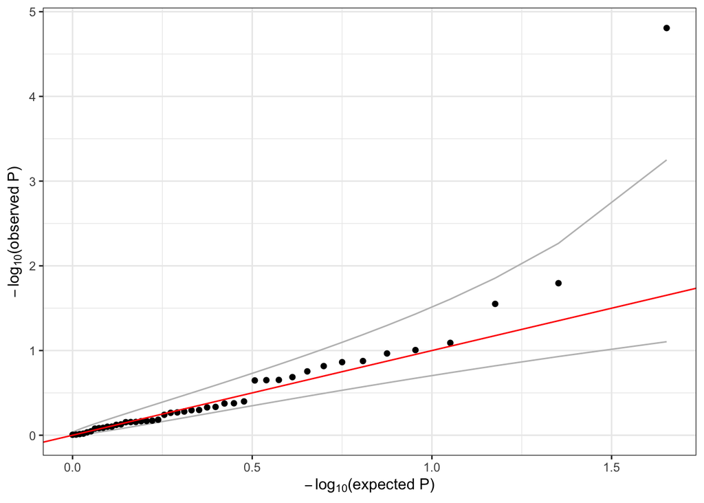

```r
library(ggplot2)
qqPlot <- function(pval) {
    pval <- pval[!is.na(pval)]
    n <- length(pval)
    x <- 1:n
    dat <- data.frame(obs=sort(pval),
                      exp=x/n,
                      upper=qbeta(0.025, x, rev(x)),
                      lower=qbeta(0.975, x, rev(x)))

    ggplot(dat, aes(-log10(exp), -log10(obs))) +
        geom_line(aes(-log10(exp), -log10(upper)), color="gray") +
        geom_line(aes(-log10(exp), -log10(lower)), color="gray") +
        geom_point() +
        geom_abline(intercept=0, slope=1, color="red") +
        xlab(expression(paste(-log[10], "(expected P)"))) +
        ylab(expression(paste(-log[10], "(observed P)"))) +
        theme_bw()
}

qqPlot(burden$Score.pval)
```

Note: QQ plots for multi-variant tests are often not as clean as for single variant GWAS, particularly in the lower part of the plot (i.e. insignificant $p$-values near to $-log_{10}(p) = 0$). However, the QQ plot can still be useful to assess egregious issues.

### SKAT Test

We can also perform a SKAT test. This time, we will use the Wu weights (i.e. drawn from a Beta(1,25) distribution), which give larger weights to rarer variants (note the different weight values in the `variantInfo` output).

```r
# reset the iterator to the first window
resetIterator(iterator, verbose = FALSE)

# run the SKAT test
assoc.skat <- assocTestAggregate(iterator,
                                 null.model = nullmod,
                                 test = "SKAT",
                                 AF.max = 0.01,
                                 weight.beta = c(1,25))
```

```
## # of selected samples: 1,040
```

```r
# results for each aggregation unit
head(assoc.skat$results)
```

```
##                 n.site n.alt n.sample.alt          Q         pval err
## ENSG00000253764     53   173          132   59644.82 0.2378400464   0
## ENSG00000215373      0     0            0         NA           NA  NA
## ENSG00000176782     41   110           97   37082.94 0.2580691317   0
## ENSG00000248538   5755 20042         1038 6014266.17 0.2735962312   0
## ENSG00000206950      0     0            0         NA           NA  NA
## ENSG00000253184   1209  4240          873 2351077.86 0.0001106246   0
##                 pval.method
## ENSG00000253764 integration
## ENSG00000215373        <NA>
## ENSG00000176782 integration
## ENSG00000248538 integration
## ENSG00000206950        <NA>
## ENSG00000253184 integration
```

Again, each row of the `results` data.frame represents one tested aggregation unit. Some of the columns are the same as for the burden test; new columns include: the SKAT statistic (`Q`), the SKAT $p$-value (`pval`), the $p$-value method used (`pval.method`), and an indicator if there was any error detected in computing the $p$-value (`err`). If any aggregation units indicate an error (value = 1), they should be dropped from the results. Note that there is no effect size provided, as there is no such concept for SKAT.

```r
table(assoc.skat$results$pval.method, assoc.skat$results$err, exclude = NULL)
```

```
##
##                0 <NA>
##   integration 44    0
##   saddlepoint  4    0
##   <NA>         0    2
```

```r
# variant info per aggregation unit
head(assoc.skat$variantInfo[[3]])
```

```
##    variant.id chr     pos allele.index n.obs         freq MAC   weight
## 4      408422   8 7836645            1  1040 0.0038461538   8 22.79156
## 6      408424   8 7836646            1  1040 0.0004807692   1 24.71313
## 7      408425   8 7836662            1  1040 0.0024038462   5 23.59687
## 13     408431   8 7836835            1  1040 0.0004807692   1 24.71313
## 15     408433   8 7836873            1  1040 0.0009615385   2 24.42941
## 17     408435   8 7836914            1  1040 0.0004807692   1 24.71313
```

The `variantInfo` for each aggregation unit includes the same information as for the burden test, but note the different variant weight values due to using the Wu weights instead of Uniform weights.

```r
# filter based on cumulative MAC
skat <- assoc.skat$results[assoc.skat$results$n.alt >= 5, ]

# significant genes
skat[skat$pval < 0.05/nrow(skat), ]
```

```
##                 n.site n.alt n.sample.alt       Q         pval err pval.method
## ENSG00000253184   1209  4240          873 2351078 0.0001106246   0 integration
```

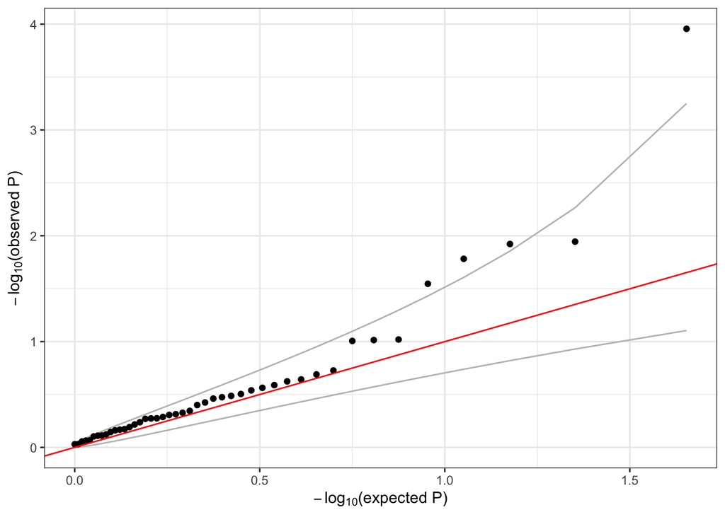

```r
# make a QQ plot of the SKAT test p-values
qqPlot(skat$pval)
```

We have one significant SKAT association at ENSG00000253184 with $p = 1.1 \times 10^{-4}$.

### SMMAT Test

We can also perform a SMMAT test, which efficiently combines the $p$-values from the burden test and an asymptotically independent adjusted “SKAT-type” test (it’s essentially a SKAT test conditional on the burden) using Fisher’s method. This method is conceptually similar to the SKAT-O test but much faster computationally.

```r
# reset the iterator to the first window
resetIterator(iterator, verbose = FALSE)

# run the SKAT test
assoc.smmat <- assocTestAggregate(iterator,
                                  null.model = nullmod,
                                  test = "SMMAT",
                                  AF.max = 0.01,
                                  weight.beta = c(1,25))
```

```
## # of selected samples: 1,040
```

```r
# results for each aggregation unit
head(assoc.smmat$results)
```

```
##                 n.site n.alt n.sample.alt Score_burden Score.SE_burden
## ENSG00000253764     53   173          132   -136.60540        254.8157
## ENSG00000215373      0     0            0           NA              NA
## ENSG00000176782     41   110           97     44.25059        193.0924
## ENSG00000248538   5755 20042         1038  -5318.01023       7919.9428
## ENSG00000206950      0     0            0           NA              NA
## ENSG00000253184   1209  4240          873   -395.78019       3314.4992
##                 Stat_burden pval_burden    Q_theta   pval_theta   pval_SMMAT
## ENSG00000253764  -0.5360948   0.5918930   58453.89 2.044668e-01 0.3765952026
## ENSG00000215373          NA          NA         NA           NA           NA
## ENSG00000176782   0.2291679   0.8187384   37127.27 2.015127e-01 0.4622737914
## ENSG00000248538  -0.6714708   0.5019207 6027887.29 2.220929e-01 0.3560418110
## ENSG00000206950          NA          NA         NA           NA           NA
## ENSG00000253184  -0.1194087   0.9049515 2349643.83 4.583332e-05 0.0004599947
##                 err pval_theta.method
## ENSG00000253764   0       integration
## ENSG00000215373  NA              <NA>
## ENSG00000176782   0       integration
## ENSG00000248538   0       integration
## ENSG00000206950  NA              <NA>
## ENSG00000253184   0       integration
```

Again, each row of the `results` data.frame represents one tested aggregation unit. Some of the columns are the same as for the burden and SKAT tests; new columns include the SMMAT combined $p$-value (`pval_SMMAT`). Note that the burden score value (`Score_burden`) and its standard error (`Score.SE_burden`), and the burden score test statistic (`Stat_burden`) and $p$-value (`pval_burden`) are included – these are the same values you would get from running the burden test. There are also columns for the SKAT-type test statistic (`Q_theta`), $p$-value (`pval_theta`), $p$-value method (`pval_theta.method`), and error indicator (`err`) – these are *not* the same values you would get from running SKAT because the “theta” component of the test has been adjusted for the burden test. Again, there is no effect size provided, as there is no such concept for the overall SMMAT test.

```r
# variant info per aggregation unit
head(assoc.smmat$variantInfo[[3]])
```

```
##    variant.id chr     pos allele.index n.obs         freq MAC   weight
## 4      408422   8 7836645            1  1040 0.0038461538   8 22.79156
## 6      408424   8 7836646            1  1040 0.0004807692   1 24.71313
## 7      408425   8 7836662            1  1040 0.0024038462   5 23.59687
## 13     408431   8 7836835            1  1040 0.0004807692   1 24.71313
## 15     408433   8 7836873            1  1040 0.0009615385   2 24.42941
## 17     408435   8 7836914            1  1040 0.0004807692   1 24.71313
```

Again, the `variantInfo` for each aggregation unit includes the same information as the other tests.

The function returns the $p$-values from the burden test (`pval_burden`), the adjusted SKAT-type test (`pval_theta`), and the combined $p$-value (`pval_SMMAT`). The combined $p$-value is the one to use for assessing significance. The burden and theta $p$-values may be of secondary interest for further exploring results.

```r
# filter based on cumulative MAC
smmat <- assoc.smmat$results[assoc.smmat$results$n.alt >= 5, ]

# significant genes
smmat[smmat$pval_SMMAT < 0.05/nrow(smmat), ]
```

```
##                 n.site n.alt n.sample.alt Score_burden Score.SE_burden
## ENSG00000253184   1209  4240          873    -395.7802       3314.4992
## ENSG00000251354     25    53           50     578.9664        131.3365
##                 Stat_burden  pval_burden    Q_theta   pval_theta   pval_SMMAT
## ENSG00000253184  -0.1194087 9.049515e-01 2349643.83 4.583332e-05 4.599947e-04
## ENSG00000251354   4.4082673 1.042009e-05   28639.65 2.561739e-02 4.307339e-06
##                 err pval_theta.method
## ENSG00000253184   0       integration
## ENSG00000251354   0       integration
```

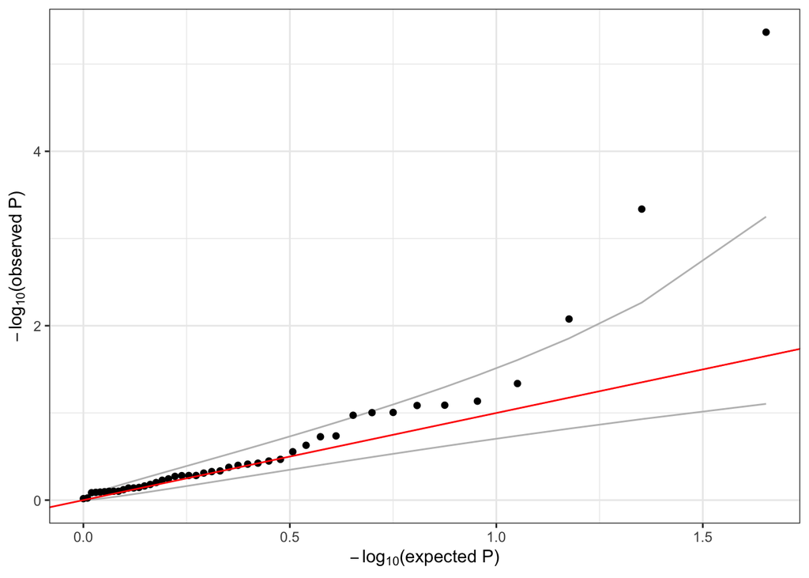

```r
# make a QQ plot of the SKAT test p-values
qqPlot(smmat$pval_SMMAT)
```

The SMMAT test found two significant genes, ENSG00000253184 and ENSG00000251354, which were the genes that the SKAT and burden tests found respectively. For ENSG00000253184, the SMMAT $p = 4.6 \times 10^{-4}$, while the SKAT $p = 1.1 \times 10^{-4}$ (see above) was slightly more significant. For ENSG00000251354, the SMMAT $p = 4.3 \times 10^{-6}$ was more significant than the burden $p = 1.0 \times 10^{-5}$ (the burden $p$-value is a bit different from earlier because we used the Wu weights instead of Uniform weights) – as seen here, the combined SMMAT $p$-value may be more significant than either burden or SKAT separately.

## Exercise 6.1 (Application)

Use the `GENESIS Aggregate Association Testing` app on the BioData Catalyst powered by Seven Bridges platform to perform gene-based SMMAT tests for trait_1 using the null model previously fit in the `02_GWAS.Rmd` tutorial. Only include variants with alternate allele frequency < 1% and use the Wu weights to upweight rarer variants. Use the genotype data in the genome-wide GDS files you created previously.

The `GENESIS Aggregate Association Testing` app currently requires Variant group files that are RData data.frames (i.e. our GRanges objects with gene defintions will not work). Fortunately, it is easy to transform our GRanges object to the required data.frame. The files you need to run the application are already in the project files on the SBG platform.

```r
# look at the GRanges object
genes
```

```
## GRanges object with 50 ranges and 1 metadata column:
##                   seqnames              ranges strand |          gene
##                      <Rle>           <IRanges>  <Rle> |   <character>
##   ENSG00000253764        8     1971153-1974637      - | RP11-439C15.4
##   ENSG00000215373        8     7287392-7290402      + |      FAM90A5P
##   ENSG00000176782        8     7836436-7841242      + |      DEFB104A
##   ENSG00000248538        8     9151695-9425524      + | RP11-115J16.1
##   ENSG00000206950        8   14332555-14332663      + |         Y_RNA
##               ...      ...                 ...    ... .           ...
##   ENSG00000223697        8 132838117-132844298      - |    AF230666.2
##   ENSG00000226807        8 141433829-141507230      - |         MROH5
##   ENSG00000198576        8 142611049-142614479      - |           ARC
##   ENSG00000253196        8 142763116-142766427      + | RP11-706C16.7
##   ENSG00000255343        8 143833270-143834063      - | RP11-299M14.2
##   -------
##   seqinfo: 23 sequences from an unspecified genome; no seqlengths
```

```r
# conver to the required data.frame
genes.df <- data.frame("group_id" = names(genes),
                       chr = seqnames(genes),
                       start = start(genes),
                       end = end(genes))
head(genes.df)
```

```
##          group_id chr    start      end
## 1 ENSG00000253764   8  1971153  1974637
## 2 ENSG00000215373   8  7287392  7290402
## 3 ENSG00000176782   8  7836436  7841242
## 4 ENSG00000248538   8  9151695  9425524
## 5 ENSG00000206950   8 14332555 14332663
## 6 ENSG00000253184   8 16604255 16664879
```

The steps to perform this analysis are as follows:

- Copy the app to your project if it is not already there:
  - Click: Public Resources > Workflows and Tools > Browse
  - Search for `GENESIS Aggregate Association Testing`
  - Click: Copy > Select your project > Copy
- Run the analysis in your project:
  - Click: Apps > `GENESIS Aggregate Association Testing` > Run
  - Specify the Inputs:
    - GDS files: `1KG_phase3_GRCh38_subset_chr<CHR>.gds` (select all 22 chromosomes)
    - Null model file: `1KG_trait_1_null_model.RData`
    - Phenotype file: `1KG_trait_1_phenotypes.RData` (use the phenotype file created by the Null Model app)
    - Variant group files: `gencode.v38.hg38_ENSG_VarGroups_subset_chr<CHR>.RData` (select all 22 chromosomes)
  - Specify the App Settings:
    - define_segments > Genome build: hg38
    - aggregate_list > Aggregate type: position
    - assoc_aggregate > Alt Freq Max: 0.01
    - assoc_aggregate > Memory GB: 32 (increase to make sure enough available)
    - assoc_aggregate > Test: smmat
    - assoc_aggregate > Weight Beta: “1 25”
    - Output prefix: “1KG_trait_1_smmat” (or any other string to name the output file)
    - GENESIS Association results plotting > Plot MAC threshold: 5
  - Click: Run

The analysis will take a few minutes to run. You can find your analysis in the Tasks menu of your Project to check on its progress and see the results once it has completed.

The output of this analysis will be 22 `<output_prefix>_chr<CHR>.RData` files with the association test results for each chromosome as well as a `<output_prefix>_manh.png` file with the Manhattan plot and a `<output_prefix>_qq.png` file with the QQ plot. Review the Manhattan plot – are there any significant gene associations?

You can find the expected output of this analysis by looking at the existing task `11 SMMAT Association Test trait_1` in the Tasks menu of your Project. The output files are available in the Project, so you do not need to wait for your analysis to finish to look at the output.

## Exercise 6.2 (Data Studio)

After running an Application, you may want to load the results into RStudio to explore them interactively. All of the output files are saved in the directory `/sbgenomics/project-files/`. Load the chromosome 8 SMMAT results into RStudio and find the significant genes.

```r
# your solution here
#
#
#
#
#
#
#
#
#
```

### Solution 6.2 (Data Studio)

After running an Application, you may want to load the results into RStudio to explore them interactively. All of the output files are saved in the directory `/sbgenomics/project-files/`. Load the chromosome 8 SMMAT results into RStudio and find the significant genes.

```r
# load
assoc <- get(load('/sbgenomics/project-files/1KG_trait_1_smmat_chr8.RData'))
names(assoc)

head(assoc$results)

# filter to cumulative MAC >= 5
smmat <- assoc$results[assoc$results$n.alt >= 5, ]

# significant genes
smmat[smmat$pval_SMMAT < 0.05/nrow(smmat), ]
```